# MP_NR97_SRF_NR97_miTags_18S_and_16S_diversity_analysis

lrubinat

06/05/2016

# 1) 18S amplicons

## 1.1) Data overview

```
## [1] 1460   13
```

```
##     OTUId st019 st030 st044 st063
## 1 OTU_410    17     2    10    20
## 2 OTU_623     2     0     5     1
## 3 OTU_728     7     1     4     9
## 4 OTU_766     9     1     7     8
## 5 OTU_793     8     0     9     5
```

```
## [1] 1460   12
```

```
##         st019 st030 st044 st063 st076
## OTU_410    17     2    10    20    12
## OTU_623     2     0     5     1    33
## OTU_728     7     1     4     9     8
## OTU_766     9     1     7     8     5
## OTU_793     8     0     9     5     9
```

```
## [1] 1460    2
```

```
##                                                                                                              taxonomic_classification
## OTU_410                    GU821879.1.1200_Eukaryota;SAR;Alveolata;Protalveolata;Syndiniales;Syndiniales_Group_II;uncultured_Rhizaria
## OTU_623         U14389.1.1816_Eukaryota;SAR;Stramenopiles;Ochrophyta;Pelagophyceae;Pelagomonadales;Pelagomonas;Pelagomonas_calceolata
## OTU_728 KC488381.1.1680_Eukaryota;SAR;Alveolata;Ciliophora;Intramacronucleata;Spirotrichea;Oligotrichia;uncultured;uncultured_ciliate
## OTU_766                                               EF173010.1.1664_Eukaryota;SAR;Stramenopiles;MAST-1;MAST-1D;uncultured_eukaryote
## OTU_793                    AY665056.1.1740_Eukaryota;SAR;Alveolata;Protalveolata;Syndiniales;Syndiniales_Group_I;uncultured_eukaryote
##                         class
## OTU_410 heterotrophic_protist
## OTU_623         Pelagophyceae
## OTU_728 heterotrophic_protist
## OTU_766 heterotrophic_protist
## OTU_793 heterotrophic_protist
```

```
## [1] 1460   10
```

```
##         st019 st030 st044 st063 st076
## OTU_410    17     2    10    20    12
## OTU_623     2     0     5     1    33
## OTU_728     7     1     4     9     8
## OTU_766     9     1     7     8     5
## OTU_793     8     0     9     5     9
```

```
## st030
##   156
```

```
## [1] 1460    9
```

```
## [1] 1460    0
```

## 1.2) Normalization

Let’s normalize the original dataset by randomly subsampling 488 reads in each station:

```r
library(vegan)
MP_NR97_18S_miTags_tax_occur_min488_t<-t(MP_NR97_18S_miTags_tax_occur_min488)
MP_NR97_18S_miTags_tax_occur_ss488<-rrarefy(MP_NR97_18S_miTags_tax_occur_min488_t, 488)
```

The normalized table shows the following dimensions and format:

```
## [1]    9 1460
```

```
##       OTU_410 OTU_623 OTU_728 OTU_766 OTU_793
## st019       7       1       5       3       4
## st044       7       5       2       4       5
## st063      14       1       7       5       4
## st076       6      16       5       3       4
## st083       8       0       7       6       2
```

Its content fits with the expected normalization values (488 reads per station):

```r
rowSums(MP_NR97_18S_miTags_tax_occur_ss488)
```

```
## st019 st044 st063 st076 st083 st092 st101 st120 st141
##   488   488   488   488   488   488   488   488   488
```

Let’s check out how many OTUs don’t appear in the new table:

```r
length(which(colSums(MP_NR97_18S_miTags_tax_occur_ss488)==0))
```

```
## [1] 350
```

```r
MP_NR97_18S_miTags_tax_occur_ss488_no_cero<-MP_NR97_18S_miTags_tax_occur_ss488[,-(which(colSums(MP_NR97_18S_miTags_tax_occur_ss488)==0))]
dim(MP_NR97_18S_miTags_tax_occur_ss488_no_cero)
```

```
## [1]    9 1110
```

## 1.3) Taxonomic composition analysis

### 1.3.1) Normalized data

Let’s add the taxonomic classification to the left OTUs by merging “MP_NR97_18S_miTags_tax_occur_ss488_no_cero” with “MP_NR97_18S_tax”:

```
## [1] 1110   12
```

```
##   Row.names st019 st044 st063 st076
## 1  OTU_1001     3     1     0     0
## 2  OTU_1036     2     2     1     4
## 3  OTU_1041     2     0     1     3
## 4  OTU_1049     1     4     0     5
## 5  OTU_1065     0     5     1     3
```

```
## [1] 1110   11
```

```
##          st019 st044 st063 st076 st083
## OTU_1001     3     1     0     0     2
## OTU_1036     2     2     1     4     5
## OTU_1041     2     0     1     3     3
## OTU_1049     1     4     0     5     3
## OTU_1065     0     5     1     3     2
```

```
## [1] 1110   12
```

```
##         st019 st044 st063 st076 st083
## OTU_410     7     7    14     6     8
## OTU_623     1     5     1    16     0
## OTU_728     5     2     7     5     7
## OTU_766     3     4     5     3     6
## OTU_793     4     5     4     4     2
```

```
## [1] 303  12
```

```
##          st019 st044 st063 st076 st083
## OTU_970      0     2     2     1     1
## OTU_1036     2     2     1     4     5
## OTU_1185     7     0     2     0     1
## OTU_1289     0     0     0     5     5
## OTU_1425     0     0     0     0     1
```

```
##          st019 st044 st063 st076 st083
## OTU_970      0     2     2     1     1
## OTU_1036     2     2     1     4     5
## OTU_1185     7     0     2     0     1
## OTU_1289     0     0     0     5     5
## OTU_1425     0     0     0     0     1
```

```
## [1] 135   9
```

```
## [1] 9
```

```
## [1] 0
```

```
## [1] 9
```

```
## [1] 9
```

```
## [1] 9
```

```
## [1] 6
```

```
## [1] 8
```

```
## [1] 5
```

```
## [1] 5
```

```
## [1] 0
```

```
## [1] 9
```

```
## [1] 0
```

```
## [1] 4
```

```
## [1] 0
```

```
## [1] 0
```

```
## [1] 0
```

```
## [1] 0
```

```
## [1] 0
```

```
## [1] 1
```

```
## [1] 0
```

```
## [1] 0
```

```
## [1] 0
```

```
## [1] 7
```

```
## [1] 0
```

```
##               Group.1   x
## 7         Dinophyceae 407
## 11   Prymnesiophyceae 379
## 10      Pelagophyceae 114
## 4       Chrysophyceae 102
## 6    Dictyochophyceae  53
## 5     Cryptomonadales  29
## 1     Bacillariophyta  24
## 9      Pavlovophyceae  11
## 2       Bolidophyceae   8
## 3  Chlorarachniophyta   8
## 8       Eustigmatales   5
## 12      Xanthophyceae   1
```

```
##               Group.1   x
## 7         Dinophyceae 135
## 4       Chrysophyceae  48
## 11   Prymnesiophyceae  41
## 1     Bacillariophyta  18
## 6    Dictyochophyceae  16
## 5     Cryptomonadales  15
## 10      Pelagophyceae  10
## 3  Chlorarachniophyta   6
## 2       Bolidophyceae   5
## 9      Pavlovophyceae   5
## 8       Eustigmatales   3
## 12      Xanthophyceae   1
```

```
##                    reads_per_class OTUs_per_class
## Bacillariophyta                 24             18
## Bolidophyceae                    8              5
## Chlorarachniophyta               8              6
## Chrysophyceae                  102             48
## Cryptomonadales                 29             15
## Dictyochophyceae                53             16
## Dinophyceae                    407            135
## Eustigmatales                    5              3
## Pavlovophyceae                  11              5
## Pelagophyceae                  114             10
## Prymnesiophyceae               379             41
## Xanthophyceae                    1              1
```

```
##                    reads_per_class OTUs_per_class samples_per_class
## Dinophyceae                    407            135                 9
## Prymnesiophyceae               379             41                 9
## Pelagophyceae                  114             10                 9
## Chrysophyceae                  102             48                 8
## Dictyochophyceae                53             16                 9
## Cryptomonadales                 29             15                 6
## Bacillariophyta                 24             18                 9
## Pavlovophyceae                  11              5                 5
## Chlorarachniophyta               8              6                 5
## Bolidophyceae                    8              5                 7
## Eustigmatales                    5              3                 4
## Xanthophyceae                    1              1                 1
```

OTUs per class vs. samples in which they occur [PLOT DESCRIPTION]

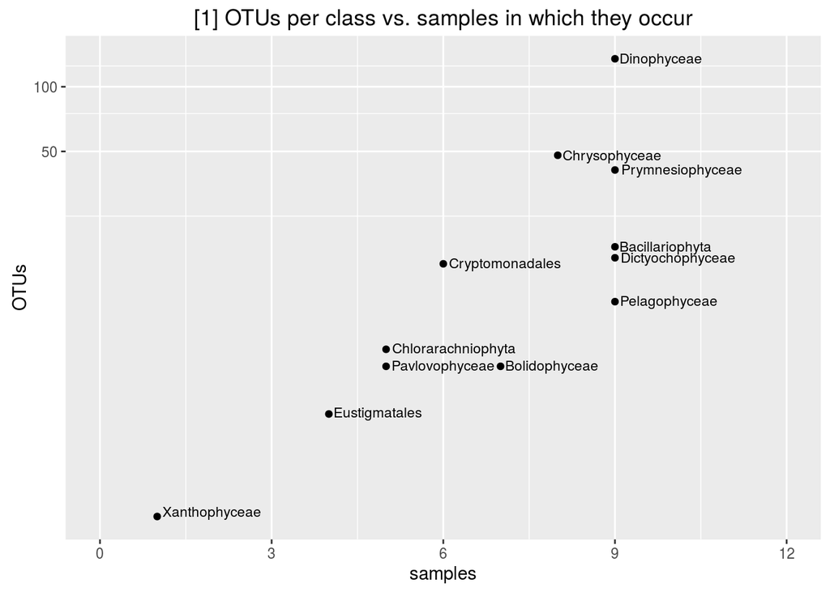

Reads per class vs. OTUs per class [PLOT DESCRIPTION]

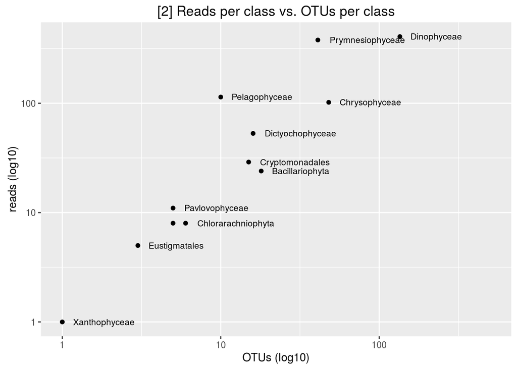

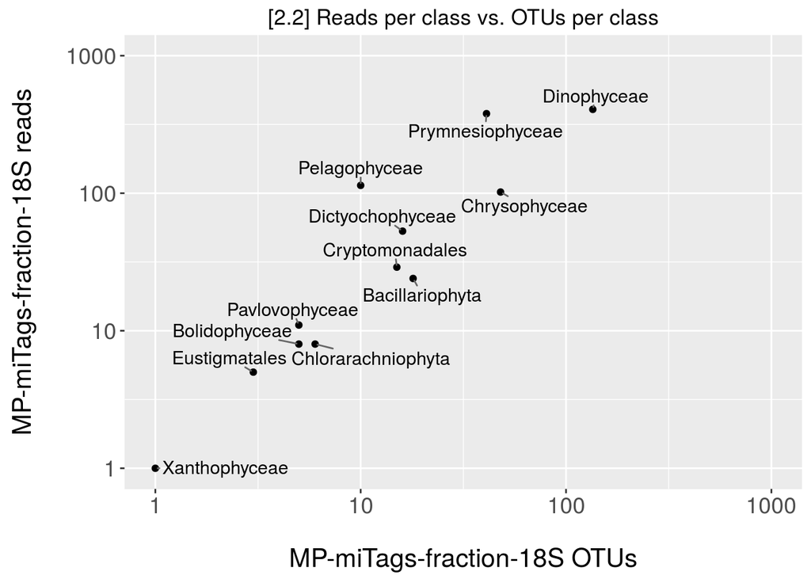

#### 1.3.1.1) Relative values

```
##   reads_per_class    OTUs_per_class samples_per_class
##               100               100               900
```

```
##                    reads_per_class OTUs_per_class samples_per_class
## Dinophyceae            35.67046450      44.554455         100.00000
## Prymnesiophyceae       33.21647677      13.531353         100.00000
## Pelagophyceae           9.99123576       3.300330         100.00000
## Chrysophyceae           8.93952673      15.841584          88.88889
## Dictyochophyceae        4.64504820       5.280528         100.00000
## Cryptomonadales         2.54163015       4.950495          66.66667
## Bacillariophyta         2.10341805       5.940594         100.00000
## Pavlovophyceae          0.96406661       1.650165          55.55556
## Chlorarachniophyta      0.70113935       1.980198          55.55556
## Bolidophyceae           0.70113935       1.650165          77.77778
## Eustigmatales           0.43821209       0.990099          44.44444
## Xanthophyceae           0.08764242       0.330033          11.11111
```

OTUs per class vs. samples in which they occur [PLOT DESCRIPTION]

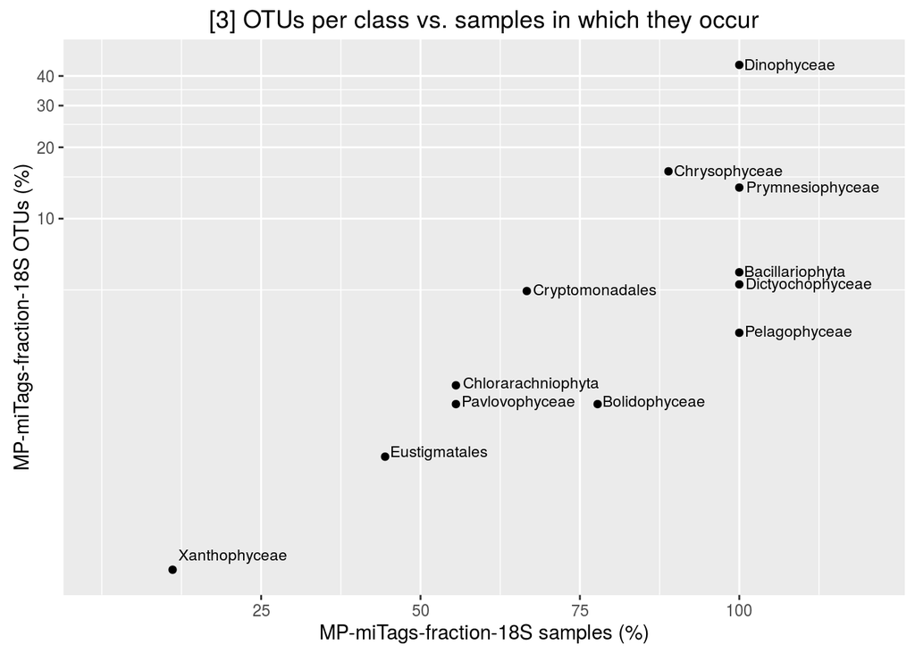

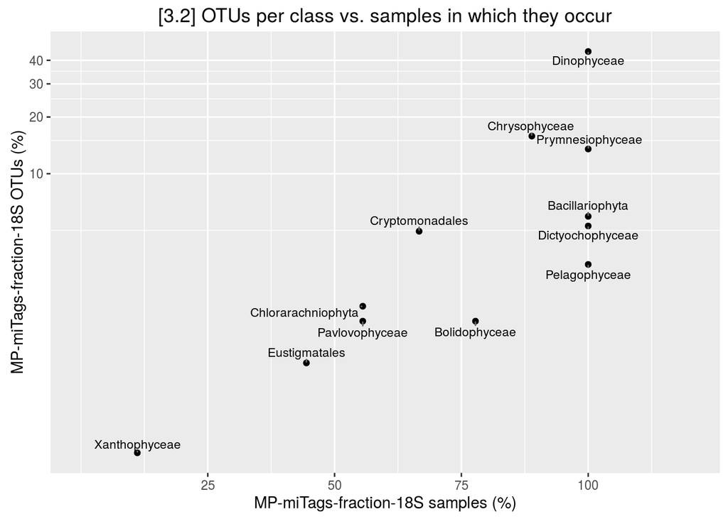

Reads per class vs. OTUs per class [PLOT DESCRIPTION]

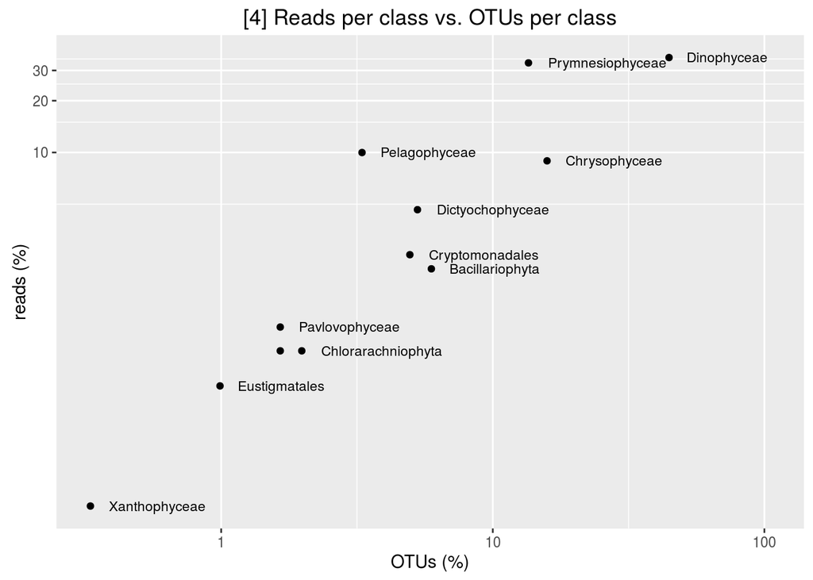

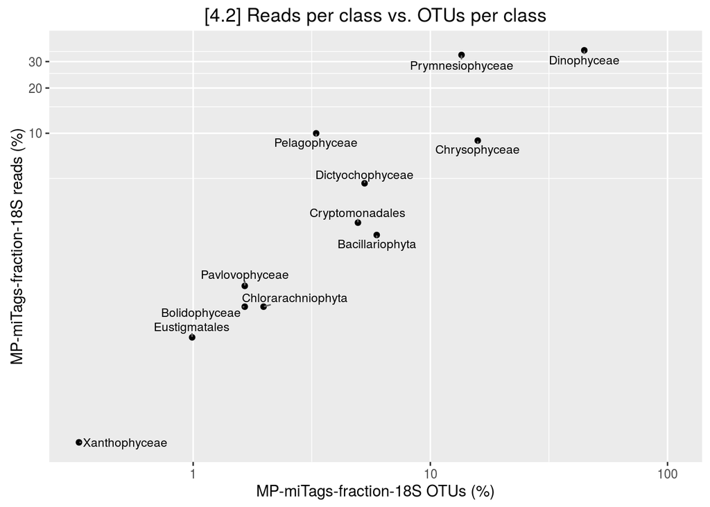

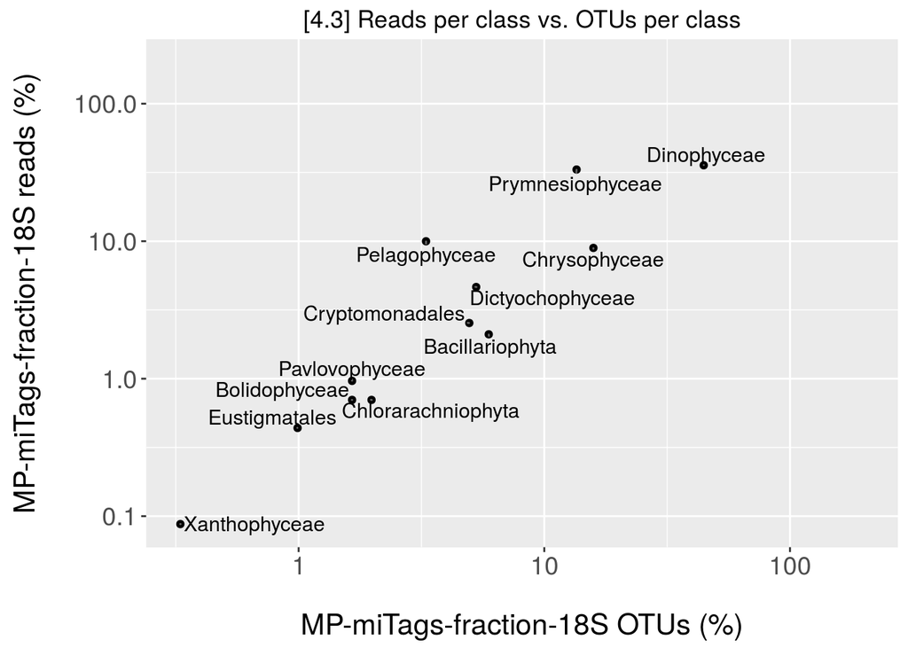

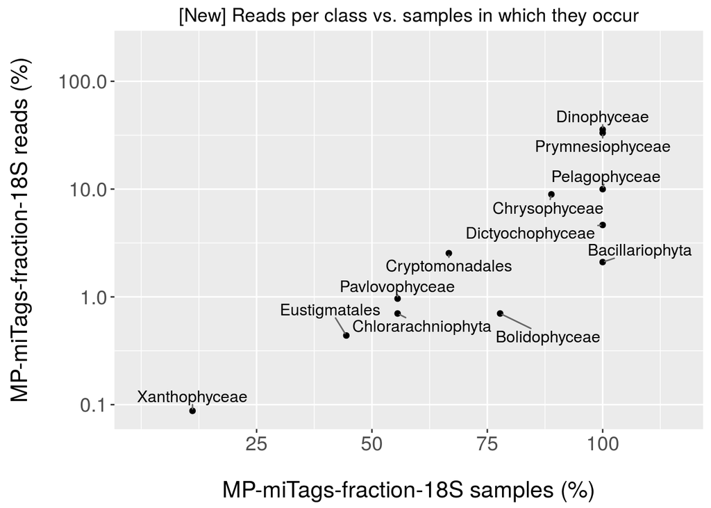

### 1.3.2) Non-normalized data

```
## [1] 1460   12
```

```
##   Row.names st019 st044 st063 st076
## 1  OTU_1001     7     5     0     2
## 2  OTU_1036     6     2     3     8
## 3  OTU_1041     2     0     1     3
## 4  OTU_1049     2     4     0     7
## 5  OTU_1065     5     7     3     5
```

```
## [1] 1460   11
```

```
##          st019 st044 st063 st076 st083
## OTU_1001     7     5     0     2     2
## OTU_1036     6     2     3     8    10
## OTU_1041     2     0     1     3    12
## OTU_1049     2     4     0     7     4
## OTU_1065     5     7     3     5     3
```

```
## [1] 1460   12
```

```
##         st019 st044 st063 st076 st083
## OTU_410    17    10    20    12    22
## OTU_623     2     5     1    33     3
## OTU_728     7     4     9     8    12
## OTU_766     9     7     8     5    15
## OTU_793     8     9     5     9     5
```

```
## [1] 395  12
```

```
##          st019 st044 st063 st076 st083
## OTU_970      1     2     5     2     7
## OTU_1036     6     2     3     8    10
## OTU_1185    11     0     2     0    10
## OTU_1289     2     1     0     7     9
## OTU_1425     1     2     1     0     4
```

```
##          st019 st044 st063 st076 st083
## OTU_970      1     2     5     2     7
## OTU_1036     6     2     3     8    10
## OTU_1185    11     0     2     0    10
## OTU_1289     2     1     0     7     9
## OTU_1425     1     2     1     0     4
```

```
## [1] 171   9
```

```
## [1] 9
```

```
## [1] 0
```

```
## [1] 9
```

```
## [1] 9
```

```
## [1] 9
```

```
## [1] 9
```

```
## [1] 8
```

```
## [1] 7
```

```
## [1] 8
```

```
## [1] 0
```

```
## [1] 9
```

```
## [1] 0
```

```
## [1] 4
```

```
## [1] 0
```

```
## [1] 0
```

```
## [1] 0
```

```
## [1] 0
```

```
## [1] 0
```

```
## [1] 2
```

```
## [1] 0
```

```
## [1] 0
```

```
## [1] 0
```

```
## [1] 8
```

```
## [1] 0
```

```
##               Group.1   x
## 7         Dinophyceae 847
## 11   Prymnesiophyceae 751
## 10      Pelagophyceae 246
## 4       Chrysophyceae 233
## 6    Dictyochophyceae 118
## 5     Cryptomonadales  65
## 1     Bacillariophyta  55
## 2       Bolidophyceae  25
## 9      Pavlovophyceae  17
## 3  Chlorarachniophyta  16
## 8       Eustigmatales   5
## 12      Xanthophyceae   2
```

```
##               Group.1   x
## 7         Dinophyceae 171
## 4       Chrysophyceae  65
## 11   Prymnesiophyceae  43
## 1     Bacillariophyta  33
## 5     Cryptomonadales  26
## 6    Dictyochophyceae  18
## 2       Bolidophyceae  10
## 10      Pelagophyceae  10
## 3  Chlorarachniophyta   9
## 9      Pavlovophyceae   6
## 8       Eustigmatales   3
## 12      Xanthophyceae   1
```

```
##                    reads_per_class OTUs_per_class
## Bacillariophyta                 55             33
## Bolidophyceae                   25             10
## Chlorarachniophyta              16              9
## Chrysophyceae                  233             65
## Cryptomonadales                 65             26
```

```
##                    reads_per_class OTUs_per_class samples_per_class
## Dinophyceae                    847            171                 9
## Prymnesiophyceae               751             43                 9
## Pelagophyceae                  246             10                 9
## Chrysophyceae                  233             65                 9
## Dictyochophyceae               118             18                 9
## Cryptomonadales                 65             26                 9
## Bacillariophyta                 55             33                 8
## Bolidophyceae                   25             10                 8
## Pavlovophyceae                  17              6                 8
## Chlorarachniophyta              16              9                 7
## Eustigmatales                    5              3                 4
## Xanthophyceae                    2              1                 2
```

```
##   reads_per_class    OTUs_per_class samples_per_class
##           100.000           100.000          1011.111
```

```
##                    reads_per_class OTUs_per_class samples_per_class
## Dinophyceae            35.58823529     43.2911392         100.00000
## Prymnesiophyceae       31.55462185     10.8860759         100.00000
## Pelagophyceae          10.33613445      2.5316456         100.00000
## Chrysophyceae           9.78991597     16.4556962         100.00000
## Dictyochophyceae        4.95798319      4.5569620         100.00000
## Cryptomonadales         2.73109244      6.5822785         100.00000
## Bacillariophyta         2.31092437      8.3544304          88.88889
## Bolidophyceae           1.05042017      2.5316456          88.88889
## Pavlovophyceae          0.71428571      1.5189873          88.88889
## Chlorarachniophyta      0.67226891      2.2784810          77.77778
## Eustigmatales           0.21008403      0.7594937          44.44444
## Xanthophyceae           0.08403361      0.2531646          22.22222
```

OTUs per class vs. samples in which they occur [PLOT DESCRIPTION]

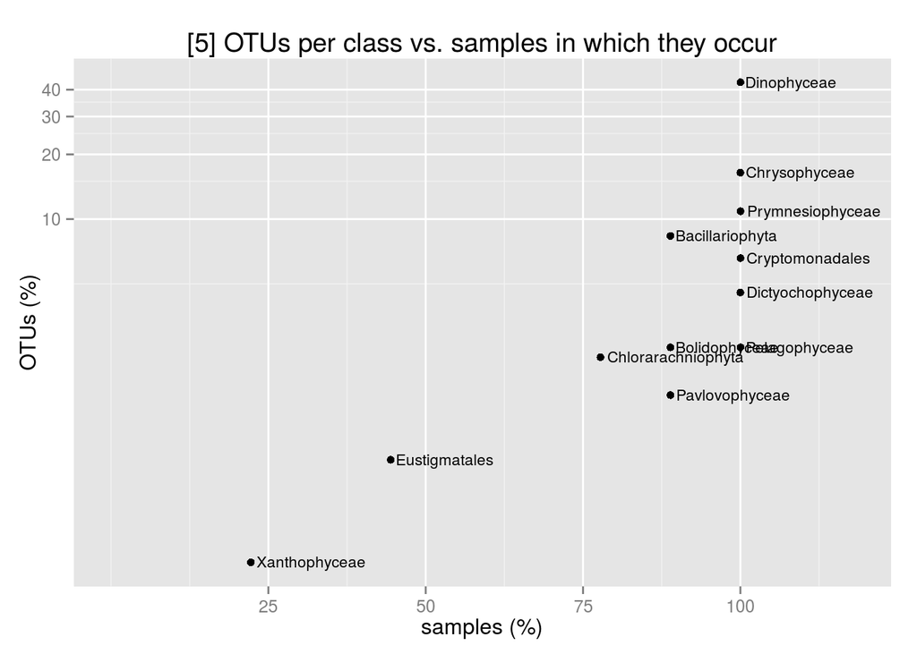

Reads per class vs. OTUs per class [PLOT DESCRIPTION]

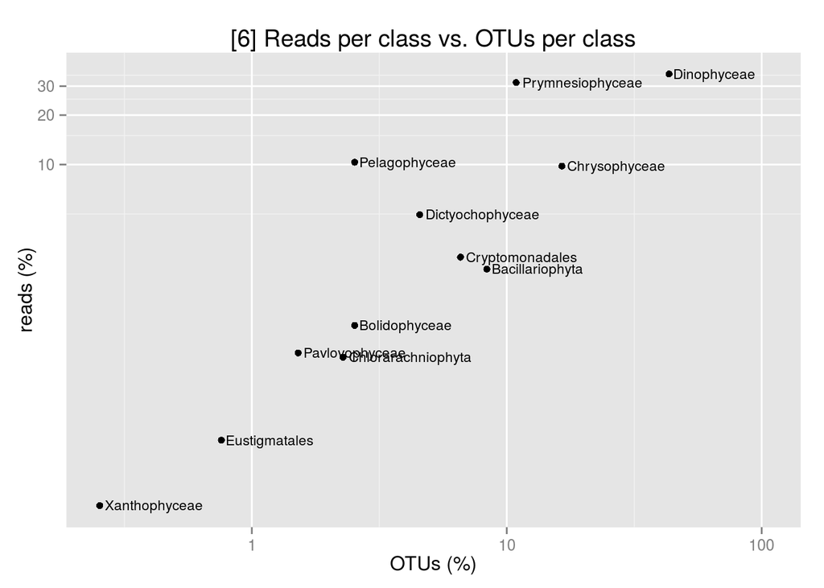

# 2) 16S amplicons

## 2.1) Data overview

```
## [1] 7189   14
```

```
##   OTUId st019 st030 st044 st063
## 1 OTU_1  1524   457   799   652
## 2 OTU_2   976   240   557   359
## 3 OTU_3   539   700   501   429
## 4 OTU_4   730   133   346   252
## 5 OTU_5   600   338   478   337
```

```
## [1] 7189   13
```

```
##       st019 st030 st044 st063 st076
## OTU_1  1524   457   799   652   262
## OTU_2   976   240   557   359   173
## OTU_3   539   700   501   429   104
## OTU_4   730   133   346   252   109
## OTU_5   600   338   478   337   143
```

```
## [1] 7189    3
```

```
##                                                                                                        taxonomic_classification
## OTU_1 KC003178.1.1230|Bacteria|Cyanobacteria|Cyanobacteria|SubsectionI|FamilyI|Prochlorococcus|unidentified|unidentified+marine
## OTU_2             EU802538.1.1286_Bacteria;Proteobacteria;Deltaproteobacteria;SAR324_clade(Marine_group_B);uncultured_bacterium
## OTU_3                    EU802992.1.1202_Bacteria;Proteobacteria;Alphaproteobacteria;SAR11_clade;Surface_1;uncultured_bacterium
## OTU_4             EU802790.1.1266_Bacteria;Cyanobacteria;Cyanobacteria;SubsectionI;FamilyI;Prochlorococcus;uncultured_bacterium
## OTU_5             EU802541.1.1287_Bacteria;Cyanobacteria;Cyanobacteria;SubsectionI;FamilyI;Prochlorococcus;uncultured_bacterium
##                      class_A                class_B
## OTU_1          Cyanobacteria        Prochlorococcus
## OTU_2 heterotrophic_bacteria heterotrophic_bacteria
## OTU_3 heterotrophic_bacteria heterotrophic_bacteria
## OTU_4          Cyanobacteria        Prochlorococcus
## OTU_5          Cyanobacteria        Prochlorococcus
```

```
## [1] 7189   10
```

```
##       st019 st030 st044 st063 st076
## OTU_1  1524   457   799   652   262
## OTU_2   976   240   557   359   173
## OTU_3   539   700   501   429   104
## OTU_4   730   133   346   252   109
## OTU_5   600   338   478   337   143
```

```
## named numeric(0)
```

```
## [1] 7189    9
```

```
##       st019 st044 st063 st076 st083
## OTU_1  1524   799   652   262  1800
## OTU_2   976   557   359   173  1130
## OTU_3   539   501   429   104   541
## OTU_4   730   346   252   109   927
## OTU_5   600   478   337   143   576
```

```
## [1] 7189    0
```

## 2.2) Normalization

Let’s normalize the original dataset by randomly subsampling 14183 reads in each station:

```r
MP_NR97_16S_miTags_tax_occur_min14183_t<-t(MP_NR97_16S_miTags_tax_occur_min14183)
MP_NR97_16S_miTags_tax_occur_ss14183<-rrarefy(MP_NR97_16S_miTags_tax_occur_min14183_t, 14183)
```

The normalized table shows the following dimensions and format:

```
## [1]    9 7189
```

```
##       OTU_1 OTU_2 OTU_3 OTU_4 OTU_5
## st019   564   377   190   281   229
## st044   322   211   205   132   185
## st063   423   212   283   155   206
## st076   132    78    50    63    67
## st083   643   431   193   357   238
```

Its content fits with the expected normalization values (14183 reads per station):

```r
rowSums(MP_NR97_16S_miTags_tax_occur_ss14183)
```

```
## st019 st044 st063 st076 st083 st092 st101 st120 st141
## 14183 14183 14183 14183 14183 14183 14183 14183 14183
```

Let’s check out how many OTUs don’t appear in the new table:

```r
length(which(colSums(MP_NR97_16S_miTags_tax_occur_ss14183)==0))
```

```
## [1] 2025
```

```r
MP_NR97_16S_miTags_tax_occur_ss14183_no_cero<-MP_NR97_16S_miTags_tax_occur_ss14183[,-(which(colSums(MP_NR97_16S_miTags_tax_occur_ss14183)==0))]
dim(MP_NR97_16S_miTags_tax_occur_ss14183_no_cero)
```

```
## [1]    9 5164
```

## 2.3) Taxonomic composition analysis

### 2.3.1) Normalized data

Let’s add the taxonomic classification to the left OTUs by merging “MP_NR97_16S_miTags_tax_occur_ss14183_no_cero” with “MP_NR97_16S_miTags_tax”.

```
## [1] 5164   13
```

```
##   Row.names st019 st044 st063 st076
## 1     OTU_1   564   322   423   132
## 2    OTU_10    91   186   157    99
## 3   OTU_100    30    12    31     4
## 4  OTU_1000     0     5     5     0
## 5  OTU_1002     5     4     0     0
```

```
## [1] 5164   12
```

```
##          st019 st044 st063 st076 st083
## OTU_1      564   322   423   132   643
## OTU_10      91   186   157    99    83
## OTU_100     30    12    31     4    24
## OTU_1000     0     5     5     0     2
## OTU_1002     5     4     0     0     3
```

```
## [1] 5164   13
```

```
##                                                                                                        taxonomic_classification
## OTU_1 KC003178.1.1230|Bacteria|Cyanobacteria|Cyanobacteria|SubsectionI|FamilyI|Prochlorococcus|unidentified|unidentified+marine
## OTU_2             EU802538.1.1286_Bacteria;Proteobacteria;Deltaproteobacteria;SAR324_clade(Marine_group_B);uncultured_bacterium
## OTU_3                    EU802992.1.1202_Bacteria;Proteobacteria;Alphaproteobacteria;SAR11_clade;Surface_1;uncultured_bacterium
## OTU_4             EU802790.1.1266_Bacteria;Cyanobacteria;Cyanobacteria;SubsectionI;FamilyI;Prochlorococcus;uncultured_bacterium
## OTU_5             EU802541.1.1287_Bacteria;Cyanobacteria;Cyanobacteria;SubsectionI;FamilyI;Prochlorococcus;uncultured_bacterium
##                      class_A
## OTU_1          Cyanobacteria
## OTU_2 heterotrophic_bacteria
## OTU_3 heterotrophic_bacteria
## OTU_4          Cyanobacteria
## OTU_5          Cyanobacteria
```

```
## [1] 271  13
```

```
## [1] 4893   13
```

```
##         st141
## OTU_231     4
## OTU_261     8
## OTU_348    26
## OTU_480     6
## OTU_497     0
##                                                        taxonomic_classification
## OTU_231 EU803047.1.1407_Bacteria;Cyanobacteria;Chloroplast;uncultured_bacterium
## OTU_261 EF574674.1.1443_Bacteria;Cyanobacteria;Chloroplast;uncultured_bacterium
## OTU_348 EF574575.1.1450_Bacteria;Cyanobacteria;Chloroplast;uncultured_bacterium
## OTU_480 EU237456.1.1310_Bacteria;Cyanobacteria;Chloroplast;uncultured_bacterium
## OTU_497 EF574484.1.1444_Bacteria;Cyanobacteria;Chloroplast;uncultured_bacterium
##                class_A        class_B
## OTU_231 other_plastids other_plastids
## OTU_261 other_plastids other_plastids
## OTU_348 other_plastids other_plastids
## OTU_480 other_plastids other_plastids
## OTU_497 other_plastids other_plastids
```

```
##       st141
## OTU_1   146
## OTU_2    79
## OTU_3   150
## OTU_4    43
## OTU_5    92
##                                                                                                        taxonomic_classification
## OTU_1 KC003178.1.1230|Bacteria|Cyanobacteria|Cyanobacteria|SubsectionI|FamilyI|Prochlorococcus|unidentified|unidentified+marine
## OTU_2             EU802538.1.1286_Bacteria;Proteobacteria;Deltaproteobacteria;SAR324_clade(Marine_group_B);uncultured_bacterium
## OTU_3                    EU802992.1.1202_Bacteria;Proteobacteria;Alphaproteobacteria;SAR11_clade;Surface_1;uncultured_bacterium
## OTU_4             EU802790.1.1266_Bacteria;Cyanobacteria;Cyanobacteria;SubsectionI;FamilyI;Prochlorococcus;uncultured_bacterium
## OTU_5             EU802541.1.1287_Bacteria;Cyanobacteria;Cyanobacteria;SubsectionI;FamilyI;Prochlorococcus;uncultured_bacterium
##                      class_A                class_B
## OTU_1          Cyanobacteria        Prochlorococcus
## OTU_2 heterotrophic_bacteria heterotrophic_bacteria
## OTU_3 heterotrophic_bacteria heterotrophic_bacteria
## OTU_4          Cyanobacteria        Prochlorococcus
## OTU_5          Cyanobacteria        Prochlorococcus
```

```r
MP_NR97_16S_miTags_class_summary_reads_per_class_protists<-aggregate(rowSums(MP_NR97_16S_miTags_protists[1:9]), list(MP_NR97_16S_miTags_protists$class_A), sum)
# count the different groups

MP_NR97_16S_miTags_class_summary_otus_per_class_protists<-aggregate(rowSums(MP_NR97_16S_miTags_protists[1:9]), list(MP_NR97_16S_miTags_protists$class_A), length)

## READS PER CLASS ##
attach(MP_NR97_16S_miTags_class_summary_reads_per_class_protists)
MP_NR97_16S_miTags_class_summary_reads_per_class_protists_order<-MP_NR97_16S_miTags_class_summary_reads_per_class_protists[order(-x),]
detach(MP_NR97_16S_miTags_class_summary_reads_per_class_protists)
MP_NR97_16S_miTags_class_summary_reads_per_class_protists_order
```

```
##               Group.1    x
## 10     other_plastids 1812
## 13   Prymnesiophyceae  251
## 12     Prasinophyceae   78
## 7    Dictyochophyceae   39
## 9     Mamiellophyceae   34
## 1     Bacillariophyta    7
## 15   Trebouxiophyceae    6
## 4       Chlorophyceae    5
## 5       Chrysophyceae    5
## 6     Cryptomonadales    4
## 3  Chlorarachniophyta    2
## 8         Dinophyceae    2
## 2       Bolidophyceae    1
## 11     Pavlovophyceae    1
## 14         Rappemonad    1
## 16        Ulvophyceae    1
```

```r
#fix column names
row.names(MP_NR97_16S_miTags_class_summary_reads_per_class_protists_order)<-MP_NR97_16S_miTags_class_summary_reads_per_class_protists_order[,1]
MP_NR97_16S_miTags_class_summary_reads_per_class_protists_order<-MP_NR97_16S_miTags_class_summary_reads_per_class_protists_order[c(-1)]
colnames(MP_NR97_16S_miTags_class_summary_reads_per_class_protists_order)<-c("reads_per_class")


## OTUs PER CLASS ##
attach(MP_NR97_16S_miTags_class_summary_otus_per_class_protists)
MP_NR97_16S_miTags_class_summary_otus_per_class_protists_order<-MP_NR97_16S_miTags_class_summary_otus_per_class_protists[order(-x),]
detach(MP_NR97_16S_miTags_class_summary_otus_per_class_protists)
MP_NR97_16S_miTags_class_summary_otus_per_class_protists_order
```

```
##               Group.1   x
## 10     other_plastids 188
## 12     Prasinophyceae  24
## 13   Prymnesiophyceae  16
## 9     Mamiellophyceae  14
## 4       Chlorophyceae   5
## 7    Dictyochophyceae   4
## 15   Trebouxiophyceae   4
## 5       Chrysophyceae   3
## 6     Cryptomonadales   3
## 1     Bacillariophyta   2
## 3  Chlorarachniophyta   2
## 8         Dinophyceae   2
## 2       Bolidophyceae   1
## 11     Pavlovophyceae   1
## 14         Rappemonad   1
## 16        Ulvophyceae   1
```

```r
row.names(MP_NR97_16S_miTags_class_summary_otus_per_class_protists_order)<-MP_NR97_16S_miTags_class_summary_otus_per_class_protists_order[,1]
MP_NR97_16S_miTags_class_summary_otus_per_class_protists_order<-MP_NR97_16S_miTags_class_summary_otus_per_class_protists_order[c(-1)]
colnames(MP_NR97_16S_miTags_class_summary_otus_per_class_protists_order)<-c("OTUs_per_class")
```

```r
MP_NR97_16S_miTags_class_summary_reads_per_class_bacteria<-aggregate(rowSums(MP_NR97_16S_miTags_bacteria[1:9]), list(MP_NR97_16S_miTags_bacteria$class_A), sum)
# count the different groups

MP_NR97_16S_miTags_class_summary_otus_per_class_bacteria<-aggregate(rowSums(MP_NR97_16S_miTags_bacteria[1:9]), list(MP_NR97_16S_miTags_bacteria$class_A), length)

## READS PER CLASS ##
attach(MP_NR97_16S_miTags_class_summary_reads_per_class_bacteria)
MP_NR97_16S_miTags_class_summary_reads_per_class_bacteria_order<-MP_NR97_16S_miTags_class_summary_reads_per_class_bacteria[order(-x),]
detach(MP_NR97_16S_miTags_class_summary_reads_per_class_bacteria)
MP_NR97_16S_miTags_class_summary_reads_per_class_bacteria_order
```

```
##                  Group.1      x
## 2 heterotrophic_bacteria 105729
## 1          Cyanobacteria  19669
```

```r
#fix column names
row.names(MP_NR97_16S_miTags_class_summary_reads_per_class_bacteria_order)<-MP_NR97_16S_miTags_class_summary_reads_per_class_bacteria_order[,1]
MP_NR97_16S_miTags_class_summary_reads_per_class_bacteria_order<-MP_NR97_16S_miTags_class_summary_reads_per_class_bacteria_order[c(-1)]
colnames(MP_NR97_16S_miTags_class_summary_reads_per_class_bacteria_order)<-c("reads_per_class")


## OTUs PER CLASS ##
attach(MP_NR97_16S_miTags_class_summary_otus_per_class_bacteria)
MP_NR97_16S_miTags_class_summary_otus_per_class_bacteria_order<-MP_NR97_16S_miTags_class_summary_otus_per_class_bacteria[order(-x),]
detach(MP_NR97_16S_miTags_class_summary_otus_per_class_bacteria)
MP_NR97_16S_miTags_class_summary_otus_per_class_bacteria_order
```

```
##                  Group.1    x
## 2 heterotrophic_bacteria 4654
## 1          Cyanobacteria  239
```

```r
row.names(MP_NR97_16S_miTags_class_summary_otus_per_class_bacteria_order)<-MP_NR97_16S_miTags_class_summary_otus_per_class_bacteria_order[,1]
MP_NR97_16S_miTags_class_summary_otus_per_class_bacteria_order<-MP_NR97_16S_miTags_class_summary_otus_per_class_bacteria_order[c(-1)]
colnames(MP_NR97_16S_miTags_class_summary_otus_per_class_bacteria_order)<-c("OTUs_per_class")
```

```
##          st019 st044 st063 st076 st083
## OTU_8052     0     1     0     0     0
## OTU_8853     0     0     0     0     0
## NA          NA    NA    NA    NA    NA
## NA.1        NA    NA    NA    NA    NA
## NA.2        NA    NA    NA    NA    NA
```

```
##          st019 st044 st063 st076 st083
## OTU_8052     0     1     0     0     0
## OTU_8853     0     0     0     0     0
## NA          NA    NA    NA    NA    NA
## NA.1        NA    NA    NA    NA    NA
## NA.2        NA    NA    NA    NA    NA
```

```
## [1] 2 9
```

```
## [1] 2
```

```
## [1] 9
```

```
## [1] 2
```

```
## [1] 0
```

```
## [1] 9
```

```
## [1] 3
```

```
## [1] 3
```

```
## [1] 2
```

```
## [1] 1
```

```
## [1] 0
```

```
## [1] 9
```

```
## [1] 7
```

```
## [1] 0
```

```
## [1] 4
```

```
## [1] 1
```

```
## [1] 0
```

```
## [1] 4
```

```
## [1] 0
```

```
## [1] 0
```

```
## [1] 0
```

```
## [1] 0
```

```
## [1] 0
```

```
## [1] 1
```

```
## [1] 1
```

```
## [1] 9
```

[BACTERIA]

```
## [1] 9
```

```
## [1] 9
```

```
##                    reads_per_class OTUs_per_class
## Bacillariophyta                  7              2
## Bolidophyceae                    1              1
## Chlorarachniophyta               2              2
## Chlorophyceae                    5              5
## Chrysophyceae                    5              3
```

```
##                    reads_per_class OTUs_per_class samples_per_class
## Prymnesiophyceae               251             16                 9
## Prasinophyceae                  78             24                 9
## Dictyochophyceae                39              4                 9
## Mamiellophyceae                 34             14                 7
## Bacillariophyta                  7              2                 3
## Trebouxiophyceae                 6              4                 4
## Chlorophyceae                    5              5                 4
## Chrysophyceae                    5              3                 2
## Cryptomonadales                  4              3                 3
## Chlorarachniophyta               2              2                 2
## Dinophyceae                      2              2                 2
## Bolidophyceae                    1              1                 1
## Pavlovophyceae                   1              1                 1
## Rappemonad                       1              1                 1
## Ulvophyceae                      1              1                 1
```

```
##                        reads_per_class OTUs_per_class
## Cyanobacteria                    19669            239
## heterotrophic_bacteria          105729           4654
## NA                                  NA             NA
## NA.1                                NA             NA
## NA.2                                NA             NA
```

```
##               reads_per_class OTUs_per_class samples_per_class
## Cyanobacteria           19669            239                 9
```

OTUs per class vs. samples in which they occur - PROTISTS [PLOT DESCRIPTION]

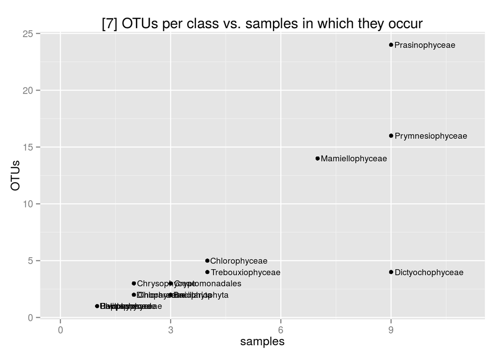

Reads per class vs. OTUs per class - PROTISTS [PLOT DESCRIPTION]

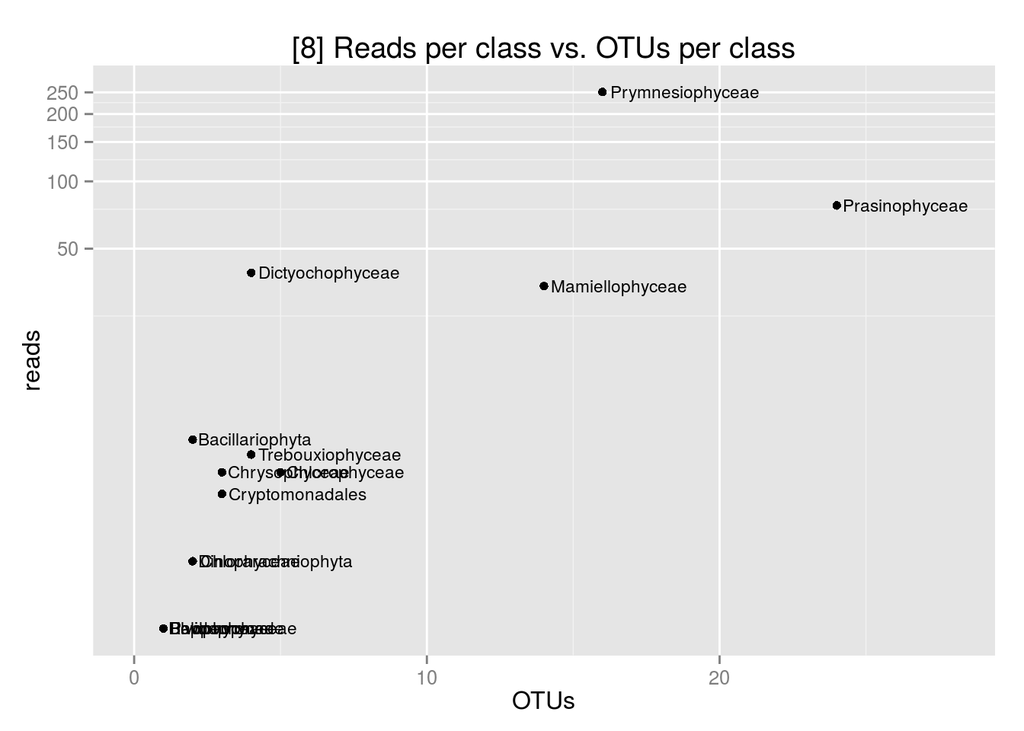

OTUs per class vs. samples in which they occur - PROTISTS vs CYANOBACTERIA [PLOT DESCRIPTION]

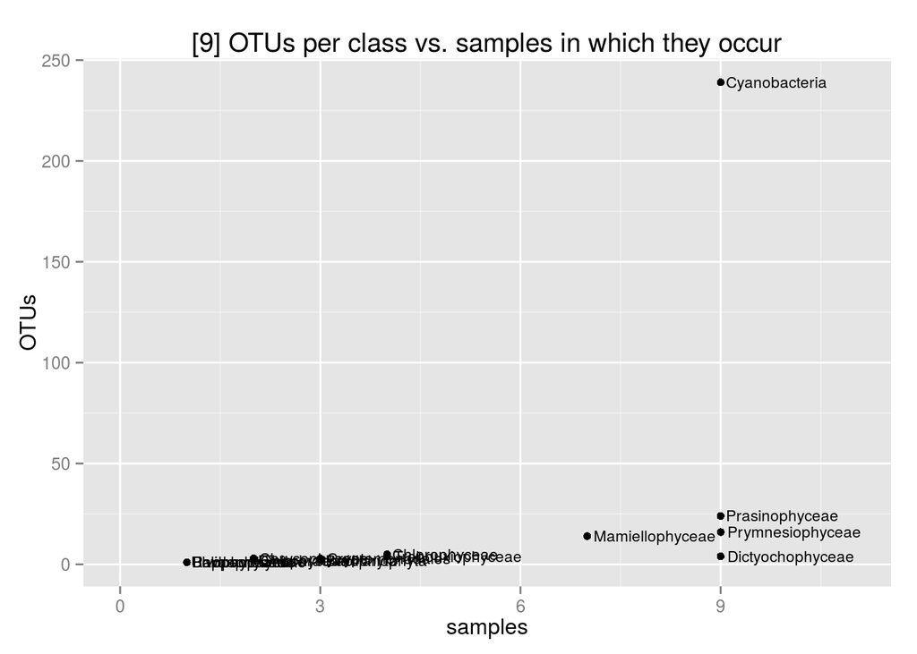

Reads per class vs. OTUs per class - PROTISTS vs CYANOBACTERIA [PLOT DESCRIPTION]

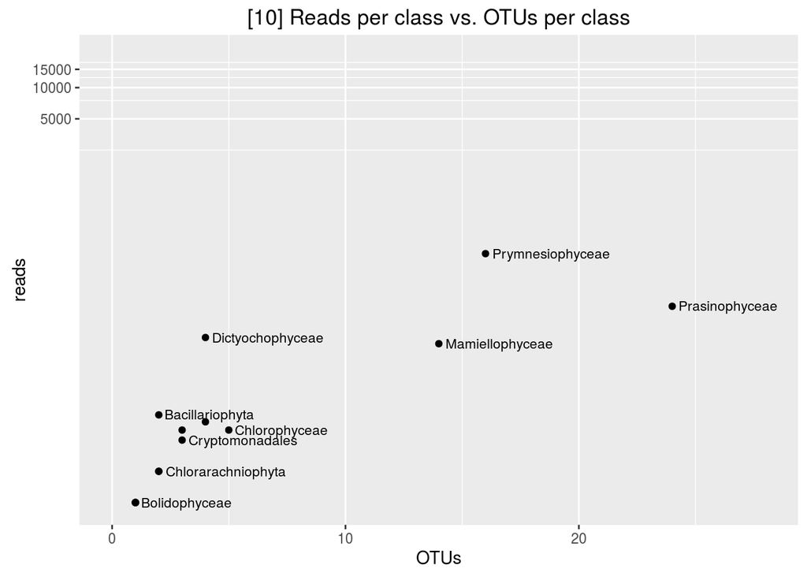

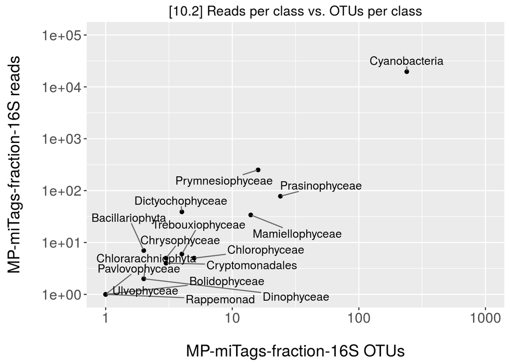

```
##   reads_per_class    OTUs_per_class samples_per_class
##          100.0000          100.0000          644.4444
```

```
##                    reads_per_class OTUs_per_class samples_per_class
## Prymnesiophyceae        57.4370709      19.277108         100.00000
## Prasinophyceae          17.8489703      28.915663         100.00000
## Dictyochophyceae         8.9244851       4.819277         100.00000
## Mamiellophyceae          7.7803204      16.867470          77.77778
## Bacillariophyta          1.6018307       2.409639          33.33333
## Trebouxiophyceae         1.3729977       4.819277          44.44444
## Chlorophyceae            1.1441648       6.024096          44.44444
## Chrysophyceae            1.1441648       3.614458          22.22222
## Cryptomonadales          0.9153318       3.614458          33.33333
## Chlorarachniophyta       0.4576659       2.409639          22.22222
## Dinophyceae              0.4576659       2.409639          22.22222
## Bolidophyceae            0.2288330       1.204819          11.11111
## Pavlovophyceae           0.2288330       1.204819          11.11111
## Rappemonad               0.2288330       1.204819          11.11111
## Ulvophyceae              0.2288330       1.204819          11.11111
```

OTUs per class vs. samples in which they occur - PROTISTS [PLOT DESCRIPTION]

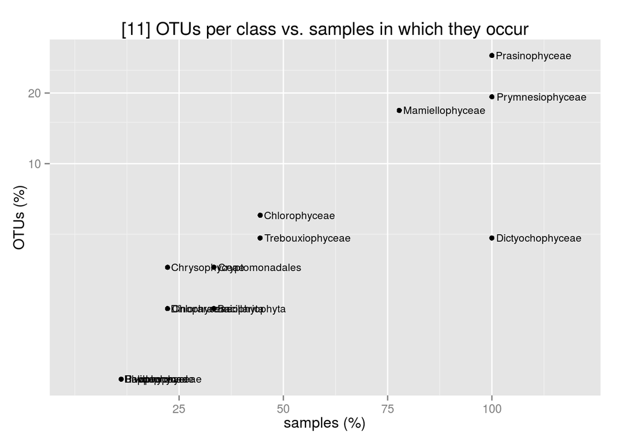

Reads per class vs. OTUs per class - PROTISTS [PLOT DESCRIPTION]

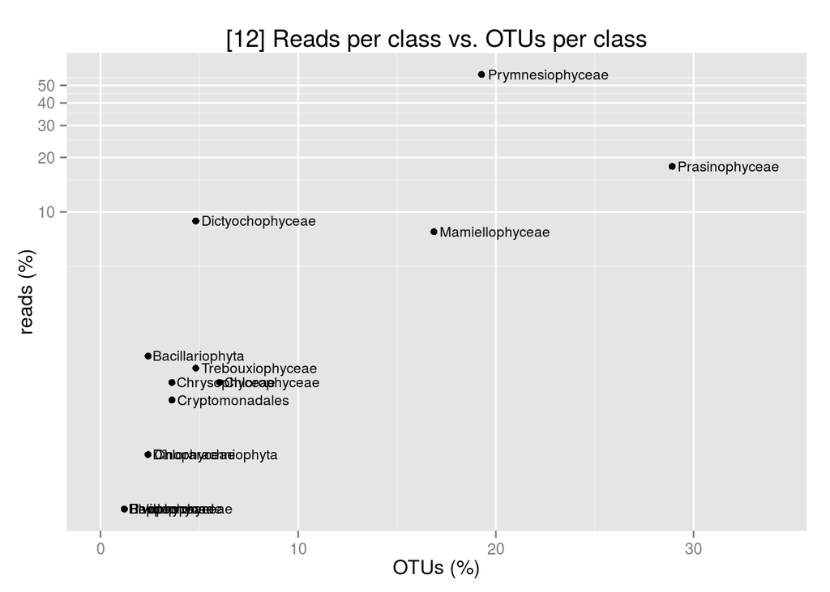

OTUs per class vs. samples in which they occur - PROTISTS vs. CYANOBACTERIA [PLOT DESCRIPTION]

```
##   reads_per_class    OTUs_per_class samples_per_class
##          100.0000          100.0000          744.4444
```

```
##                    reads_per_class OTUs_per_class samples_per_class
## Prymnesiophyceae       1.248383567       4.968944         100.00000
## Prasinophyceae         0.387943897       7.453416         100.00000
## Dictyochophyceae       0.193971949       1.242236         100.00000
## Mamiellophyceae        0.169103750       4.347826          77.77778
## Bacillariophyta        0.034815478       0.621118          33.33333
## Trebouxiophyceae       0.029841838       1.242236          44.44444
## Chlorophyceae          0.024868199       1.552795          44.44444
## Chrysophyceae          0.024868199       0.931677          22.22222
## Cryptomonadales        0.019894559       0.931677          33.33333
## Chlorarachniophyta     0.009947279       0.621118          22.22222
## Dinophyceae            0.009947279       0.621118          22.22222
## Bolidophyceae          0.004973640       0.310559          11.11111
## Pavlovophyceae         0.004973640       0.310559          11.11111
## Rappemonad             0.004973640       0.310559          11.11111
## Ulvophyceae            0.004973640       0.310559          11.11111
## Cyanobacteria         97.826519447      74.223602         100.00000
```

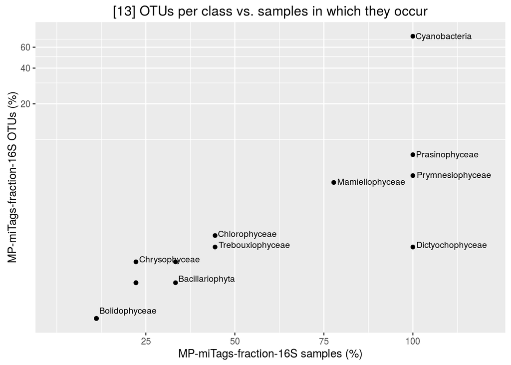

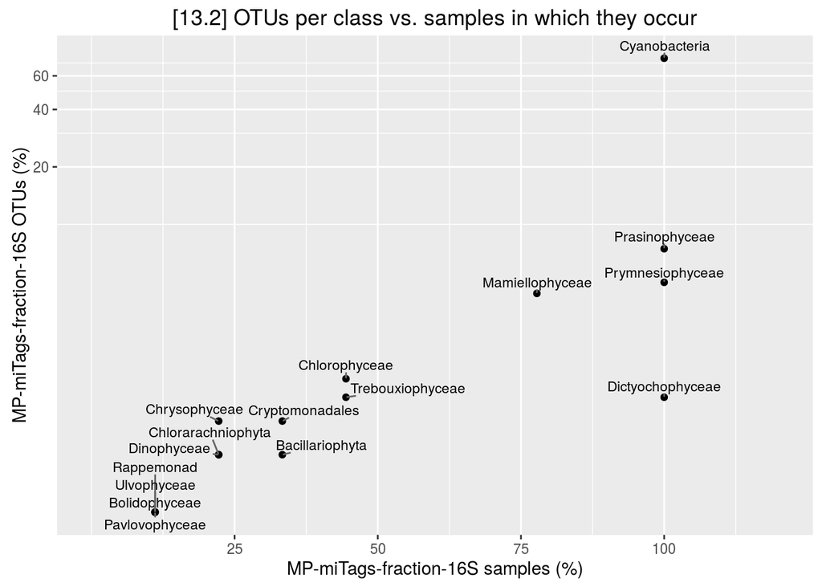

Reads per class vs. OTUs per class - PROTISTS vs CYANOBACTERIA [PLOT DESCRIPTION]

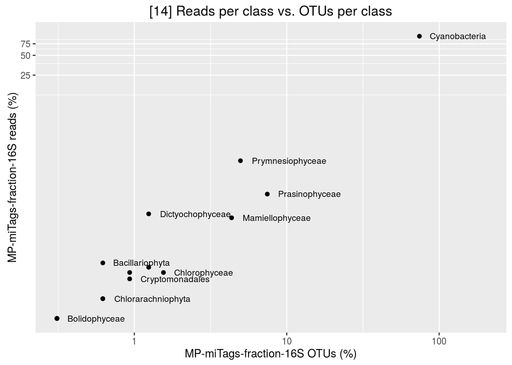

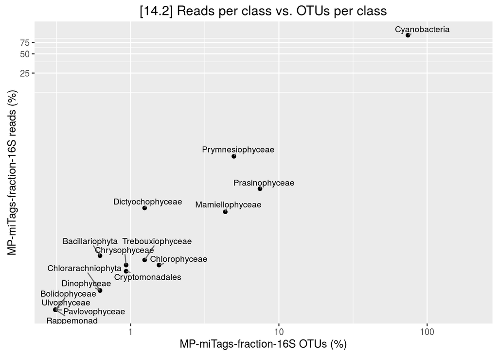

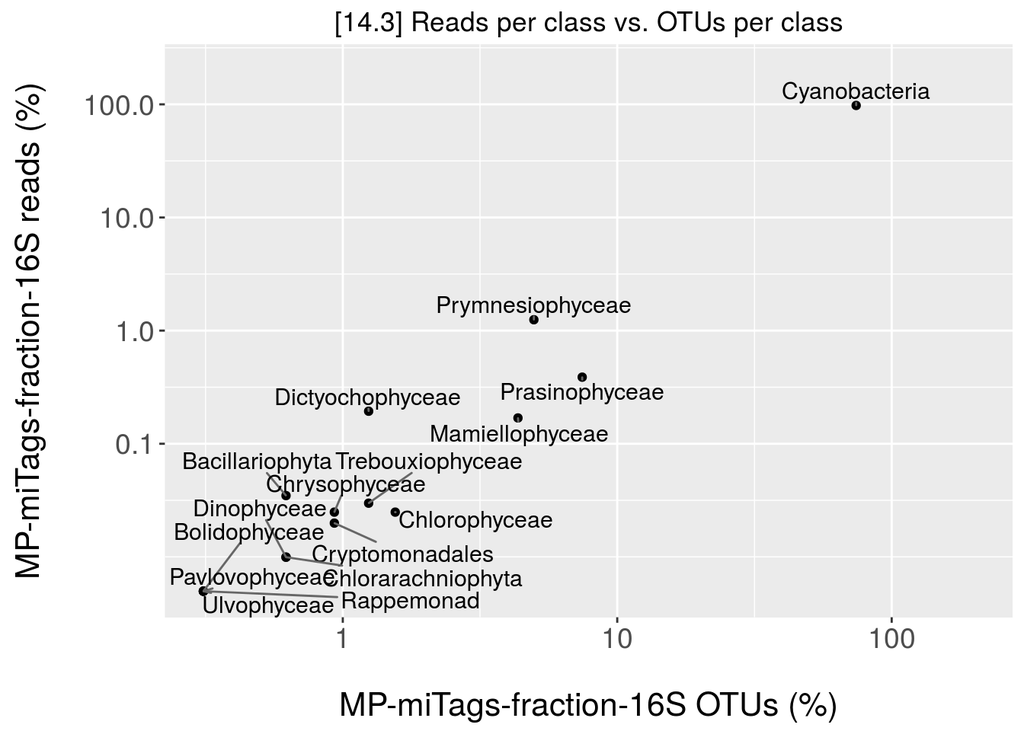

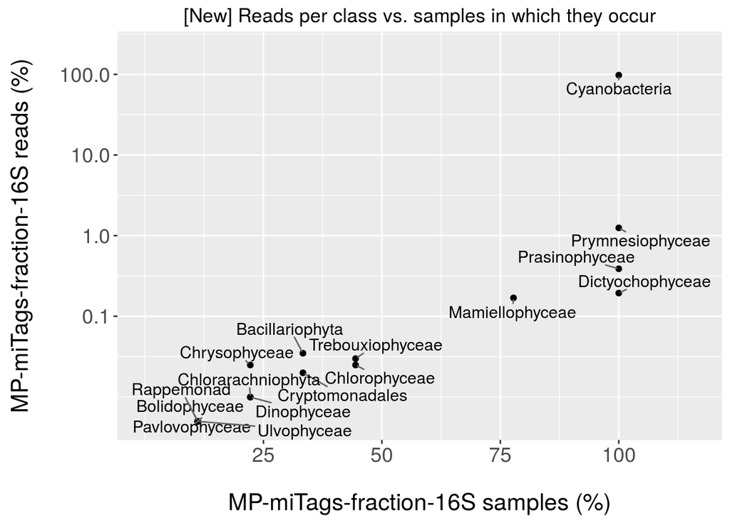

### 2.3.2) Non-normalized data

```
## [1] 7189   13
```

```
##   Row.names st019 st044 st063 st076
## 1     OTU_1  1524   799   652   262
## 2    OTU_10   265   511   287   203
## 3   OTU_100    80    47    46    14
## 4  OTU_1000     2     9     6     3
## 5  OTU_1002    11    11     0     0
```

```
## [1] 7189   12
```

```
##          st019 st044 st063 st076 st083
## OTU_1     1524   799   652   262  1800
## OTU_10     265   511   287   203   220
## OTU_100     80    47    46    14    67
## OTU_1000     2     9     6     3     2
## OTU_1002    11    11     0     0    11
```

```
## [1] 7189   13
```

```
##       st019 st044 st063 st076 st083
## OTU_1  1524   799   652   262  1800
## OTU_2   976   557   359   173  1130
## OTU_3   539   501   429   104   541
## OTU_4   730   346   252   109   927
## OTU_5   600   478   337   143   576
```

```
## [1] 358  13
```

```
## [1] 6831   13
```

```
##         st019 st044 st063 st076 st083 st092 st101 st120 st141
## OTU_231    42    28    11    15    41    36    14    31    21
## OTU_261    16    39    23    22    23    56     1    11    19
## OTU_348    27    16    15     4    31    19    15     4    47
## OTU_480    32     3    37     1     6     7    22     3    14
## OTU_497    27     1     4     4    27     4    24    23     7
##                                                        taxonomic_classification
## OTU_231 EU803047.1.1407_Bacteria;Cyanobacteria;Chloroplast;uncultured_bacterium
## OTU_261 EF574674.1.1443_Bacteria;Cyanobacteria;Chloroplast;uncultured_bacterium
## OTU_348 EF574575.1.1450_Bacteria;Cyanobacteria;Chloroplast;uncultured_bacterium
## OTU_480 EU237456.1.1310_Bacteria;Cyanobacteria;Chloroplast;uncultured_bacterium
## OTU_497 EF574484.1.1444_Bacteria;Cyanobacteria;Chloroplast;uncultured_bacterium
##                class_A        class_B OTU_no
## OTU_231 other_plastids other_plastids    231
## OTU_261 other_plastids other_plastids    261
## OTU_348 other_plastids other_plastids    348
## OTU_480 other_plastids other_plastids    480
## OTU_497 other_plastids other_plastids    497
```

```
##       st019 st044 st063 st076 st083 st092 st101 st120 st141
## OTU_1  1524   799   652   262  1800  1042   601   597   426
## OTU_2   976   557   359   173  1130   699   387   392   204
## OTU_3   539   501   429   104   541   556    77    89   362
## OTU_4   730   346   252   109   927   404   308   346   189
## OTU_5   600   478   337   143   576   480   123   162   272
##                                                                                                        taxonomic_classification
## OTU_1 KC003178.1.1230|Bacteria|Cyanobacteria|Cyanobacteria|SubsectionI|FamilyI|Prochlorococcus|unidentified|unidentified+marine
## OTU_2             EU802538.1.1286_Bacteria;Proteobacteria;Deltaproteobacteria;SAR324_clade(Marine_group_B);uncultured_bacterium
## OTU_3                    EU802992.1.1202_Bacteria;Proteobacteria;Alphaproteobacteria;SAR11_clade;Surface_1;uncultured_bacterium
## OTU_4             EU802790.1.1266_Bacteria;Cyanobacteria;Cyanobacteria;SubsectionI;FamilyI;Prochlorococcus;uncultured_bacterium
## OTU_5             EU802541.1.1287_Bacteria;Cyanobacteria;Cyanobacteria;SubsectionI;FamilyI;Prochlorococcus;uncultured_bacterium
##                      class_A                class_B OTU_no
## OTU_1          Cyanobacteria        Prochlorococcus      1
## OTU_2 heterotrophic_bacteria heterotrophic_bacteria      2
## OTU_3 heterotrophic_bacteria heterotrophic_bacteria      3
## OTU_4          Cyanobacteria        Prochlorococcus      4
## OTU_5          Cyanobacteria        Prochlorococcus      5
```

```r
class_summary_reads_per_class_16S_protists_non.norm<-aggregate(rowSums(MP_NR97_16S_miTags_protists_non.norm[1:9]), list(MP_NR97_16S_miTags_protists_non.norm$class_A), sum)
# count the different groups

class_summary_otus_per_class_16S_protists_non.norm<-aggregate(rowSums(MP_NR97_16S_miTags_protists_non.norm[1:9]), list(MP_NR97_16S_miTags_protists_non.norm$class_A), length)

## READS PER CLASS ##
attach(class_summary_reads_per_class_16S_protists_non.norm)
class_summary_reads_per_class_16S_protists_non.norm_order<-class_summary_reads_per_class_16S_protists_non.norm[order(-x),]
detach(class_summary_reads_per_class_16S_protists_non.norm)
class_summary_reads_per_class_16S_protists_non.norm_order
```

```
##                Group.1    x
## 12      other_plastids 4017
## 15    Prymnesiophyceae  505
## 14      Prasinophyceae  188
## 8     Dictyochophyceae   86
## 10     Mamiellophyceae   72
## 1      Bacillariophyta   22
## 18    Trebouxiophyceae   16
## 6        Chrysophyceae   14
## 5        Chlorophyceae   10
## 2        Bolidophyceae    8
## 16          Rappemonad    6
## 7      Cryptomonadales    4
## 3   Chlorarachniophyta    3
## 11        Nephroselmis    3
## 9          Dinophyceae    2
## 13      Pavlovophyceae    2
## 17          Rhodophyta    2
## 4  Chlorodendrophyceae    1
## 19         Ulvophyceae    1
```

```r
#fix column names
row.names(class_summary_reads_per_class_16S_protists_non.norm_order)<-class_summary_reads_per_class_16S_protists_non.norm_order[,1]
class_summary_reads_per_class_16S_protists_non.norm_order<-class_summary_reads_per_class_16S_protists_non.norm_order[c(-1)]
colnames(class_summary_reads_per_class_16S_protists_non.norm_order)<-c("reads_per_class")


## OTUs PER CLASS ##
attach(class_summary_otus_per_class_16S_protists_non.norm)
class_summary_otus_per_class_16S_protists_non.norm_order<-class_summary_otus_per_class_16S_protists_non.norm[order(-x),]
detach(class_summary_otus_per_class_16S_protists_non.norm)
class_summary_otus_per_class_16S_protists_non.norm_order
```

```
##                Group.1   x
## 12      other_plastids 246
## 14      Prasinophyceae  28
## 10     Mamiellophyceae  21
## 15    Prymnesiophyceae  17
## 5        Chlorophyceae   8
## 18    Trebouxiophyceae   8
## 1      Bacillariophyta   7
## 6        Chrysophyceae   4
## 8     Dictyochophyceae   4
## 7      Cryptomonadales   3
## 3   Chlorarachniophyta   2
## 9          Dinophyceae   2
## 11        Nephroselmis   2
## 2        Bolidophyceae   1
## 4  Chlorodendrophyceae   1
## 13      Pavlovophyceae   1
## 16          Rappemonad   1
## 17          Rhodophyta   1
## 19         Ulvophyceae   1
```

```r
row.names(class_summary_otus_per_class_16S_protists_non.norm_order)<-class_summary_otus_per_class_16S_protists_non.norm_order[,1]
class_summary_otus_per_class_16S_protists_non.norm_order<-class_summary_otus_per_class_16S_protists_non.norm_order[c(-1)]
colnames(class_summary_otus_per_class_16S_protists_non.norm_order)<-c("OTUs_per_class")
```

```r
class_summary_reads_per_class_16S_bacteria_non.norm<-aggregate(rowSums(MP_NR97_16S_miTags_bacteria_non.norm[1:9]), list(MP_NR97_16S_miTags_bacteria_non.norm$class_A), sum)
# count the different groups

class_summary_otus_per_class_16S_bacteria_non.norm<-aggregate(rowSums(MP_NR97_16S_miTags_bacteria_non.norm[1:9]), list(MP_NR97_16S_miTags_bacteria_non.norm$class_A), length)

## READS PER CLASS ##
attach(class_summary_reads_per_class_16S_bacteria_non.norm)
class_summary_reads_per_class_16S_bacteria_non.norm_order<-class_summary_reads_per_class_16S_bacteria_non.norm[order(-x),]
detach(class_summary_reads_per_class_16S_bacteria_non.norm)
class_summary_reads_per_class_16S_bacteria_non.norm_order
```

```
##                  Group.1      x
## 2 heterotrophic_bacteria 232355
## 1          Cyanobacteria  42253
```

```r
#fix column names
row.names(class_summary_reads_per_class_16S_bacteria_non.norm_order)<-class_summary_reads_per_class_16S_bacteria_non.norm_order[,1]
class_summary_reads_per_class_16S_bacteria_non.norm_order<-class_summary_reads_per_class_16S_bacteria_non.norm_order[c(-1)]
colnames(class_summary_reads_per_class_16S_bacteria_non.norm_order)<-c("reads_per_class")


## OTUs PER CLASS ##
attach(class_summary_otus_per_class_16S_bacteria_non.norm)
class_summary_otus_per_class_16S_bacteria_non.norm_order<-class_summary_otus_per_class_16S_bacteria_non.norm[order(-x),]
detach(class_summary_otus_per_class_16S_bacteria_non.norm)
class_summary_otus_per_class_16S_bacteria_non.norm_order
```

```
##                  Group.1    x
## 2 heterotrophic_bacteria 6550
## 1          Cyanobacteria  281
```

```r
row.names(class_summary_otus_per_class_16S_bacteria_non.norm_order)<-class_summary_otus_per_class_16S_bacteria_non.norm_order[,1]
class_summary_otus_per_class_16S_bacteria_non.norm_order<-class_summary_otus_per_class_16S_bacteria_non.norm_order[c(-1)]
colnames(class_summary_otus_per_class_16S_bacteria_non.norm_order)<-c("OTUs_per_class")
```

```
##          st019 st044 st063 st076 st083
## OTU_8052     0     1     0     0     0
## OTU_8853     0     0     0     0     0
## NA          NA    NA    NA    NA    NA
## NA.1        NA    NA    NA    NA    NA
## NA.2        NA    NA    NA    NA    NA
```

```
##          st019 st044 st063 st076 st083
## OTU_8052     0     1     0     0     0
## OTU_8853     0     0     0     0     0
## NA          NA    NA    NA    NA    NA
## NA.1        NA    NA    NA    NA    NA
## NA.2        NA    NA    NA    NA    NA
```

```
## [1] 2 9
```

```
## [1] 2
```

```
## [1] 9
```

```
## [1] 4
```

```
## [1] 0
```

```
## [1] 9
```

```
## [1] 3
```

```
## [1] 5
```

```
## [1] 2
```

```
## [1] 3
```

```
## [1] 0
```

```
## [1] 9
```

```
## [1] 7
```

```
## [1] 0
```

```
## [1] 4
```

```
## [1] 1
```

```
## [1] 0
```

```
## [1] 5
```

```
## [1] 0
```

```
## [1] 0
```

```
## [1] 1
```

```
## [1] 2
```

```
## [1] 1
```

```
## [1] 2
```

```
## [1] 4
```

```
## [1] 9
```

[[BACTERIA]]

```
## [1] 9
```

```
## [1] 9
```

```
##                     reads_per_class OTUs_per_class
## Bacillariophyta                  22              7
## Bolidophyceae                     8              1
## Chlorarachniophyta                3              2
## Chlorodendrophyceae               1              1
## Chlorophyceae                    10              8
```

```
##                        reads_per_class OTUs_per_class
## Cyanobacteria                    42253            281
## heterotrophic_bacteria          232355           6550
## NA                                  NA             NA
## NA.1                                NA             NA
## NA.2                                NA             NA
```

```
##   reads_per_class    OTUs_per_class samples_per_class
##          100.0000          100.0000          811.1111
```

```
##                     reads_per_class OTUs_per_class samples_per_class
## Prymnesiophyceae         53.4391534     15.1785714         100.00000
## Prasinophyceae           19.8941799     25.0000000         100.00000
## Dictyochophyceae          9.1005291      3.5714286         100.00000
## Mamiellophyceae           7.6190476     18.7500000          77.77778
## Bacillariophyta           2.3280423      6.2500000          55.55556
## Trebouxiophyceae          1.6931217      7.1428571          55.55556
## Chrysophyceae             1.4814815      3.5714286          44.44444
## Chlorophyceae             1.0582011      7.1428571          44.44444
## Bolidophyceae             0.8465608      0.8928571          33.33333
## Rappemonad                0.6349206      0.8928571          44.44444
## Cryptomonadales           0.4232804      2.6785714          33.33333
## Chlorarachniophyta        0.3174603      1.7857143          22.22222
## Nephroselmis              0.3174603      1.7857143          22.22222
## Dinophyceae               0.2116402      1.7857143          22.22222
## Pavlovophyceae            0.2116402      0.8928571          22.22222
## Rhodophyta                0.2116402      0.8928571          11.11111
## Chlorodendrophyceae       0.1058201      0.8928571          11.11111
## Ulvophyceae               0.1058201      0.8928571          11.11111
```

OTUs per class vs. samples in which they occur - PROTISTS [PLOT DESCRIPTION]

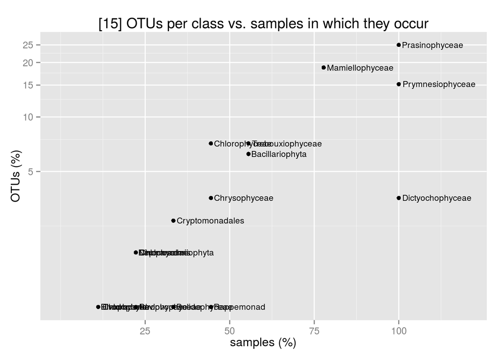

Reads per class vs. OTUs per class - PROTISTS [PLOT DESCRIPTION]

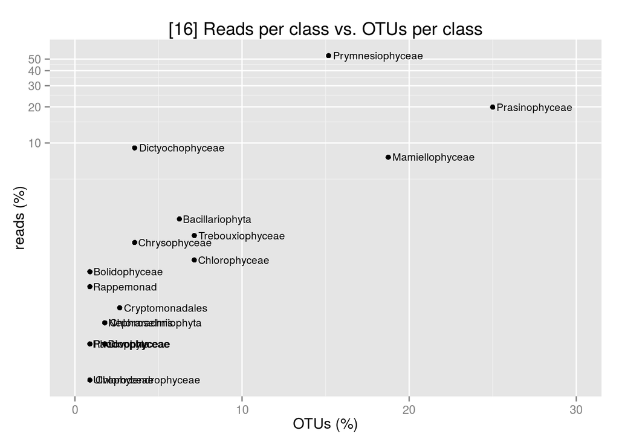

OTUs per class vs. samples in which they occur - PROTISTS vs. CYANOBACTERIA [PLOT DESCRIPTION]

```
##   reads_per_class    OTUs_per_class samples_per_class
##          100.0000          100.0000          911.1111
```

```
##                     reads_per_class OTUs_per_class samples_per_class
## Prymnesiophyceae        1.169035604      4.3256997         100.00000
## Prasinophyceae          0.435205334      7.1246819         100.00000
## Dictyochophyceae        0.199083291      1.0178117         100.00000
## Mamiellophyceae         0.166674383      5.3435115          77.77778
## Bacillariophyta         0.050928284      1.7811705          55.55556
## Trebouxiophyceae        0.037038752      2.0356234          55.55556
## Chrysophyceae           0.032408908      1.0178117          44.44444
## Chlorophyceae           0.023149220      2.0356234          44.44444
## Bolidophyceae           0.018519376      0.2544529          33.33333
## Rappemonad              0.013889532      0.2544529          44.44444
## Cryptomonadales         0.009259688      0.7633588          33.33333
## Chlorarachniophyta      0.006944766      0.5089059          22.22222
## Nephroselmis            0.006944766      0.5089059          22.22222
## Dinophyceae             0.004629844      0.5089059          22.22222
## Pavlovophyceae          0.004629844      0.2544529          22.22222
## Rhodophyta              0.004629844      0.2544529          11.11111
## Chlorodendrophyceae     0.002314922      0.2544529          11.11111
## Ulvophyceae             0.002314922      0.2544529          11.11111
## Cyanobacteria          97.812398722     71.5012723         100.00000
```

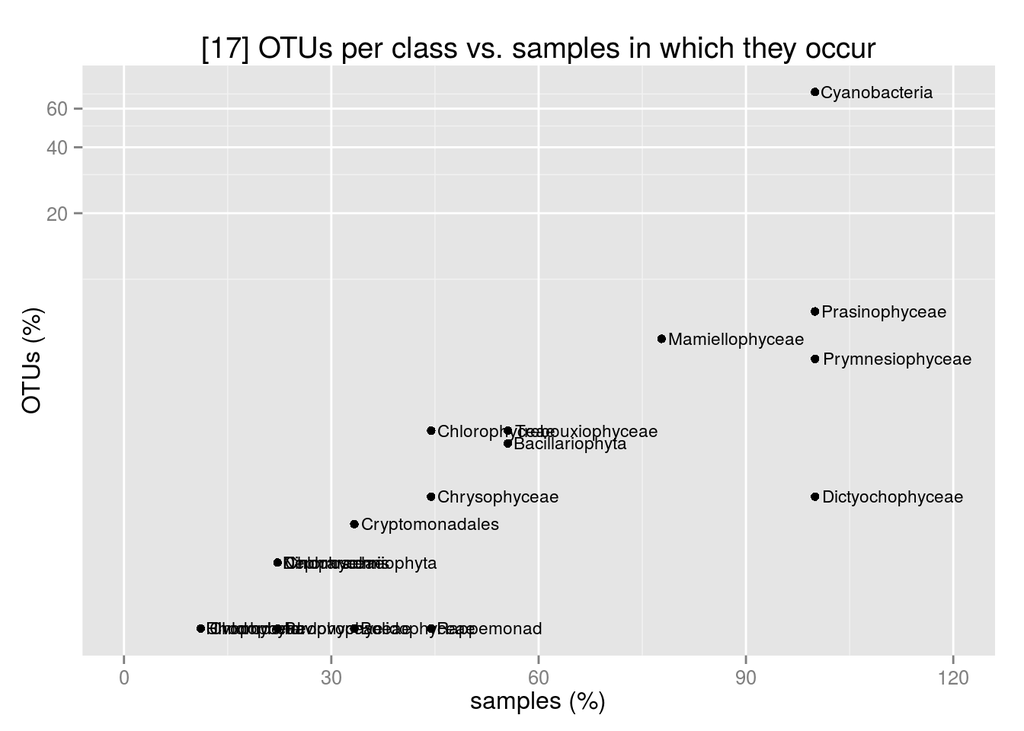

Reads per class vs. OTUs per class - PROTISTS vs CYANOBACTERIA [PLOT DESCRIPTION]

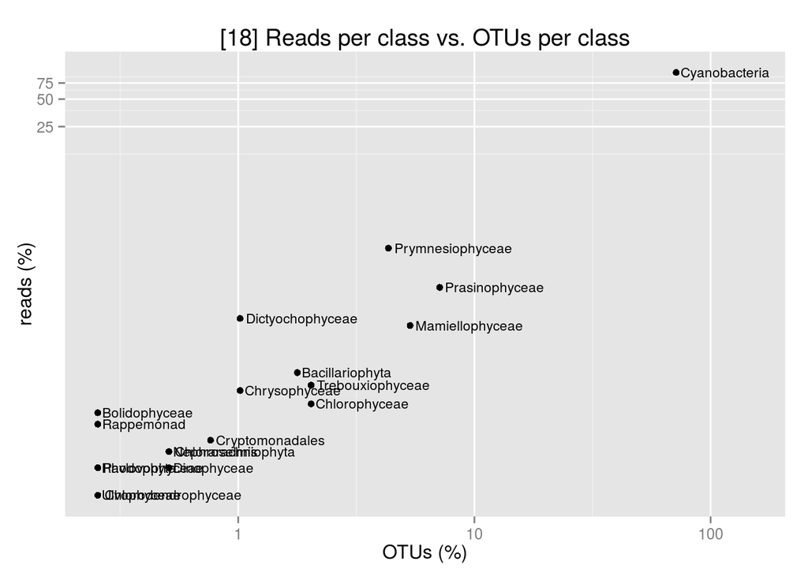

```r
cyano_tb <- MP_NR97_16S_miTags_bacteria[which(MP_NR97_16S_miTags_bacteria$class_A != "heterotrophic_bacteria"),]

class_summary_reads_per_class_cyano<-aggregate(rowSums(cyano_tb[1:9]), list(cyano_tb$class_B), sum)
# count the different groups
class_summary_otus_per_class_cyano<-aggregate(rowSums(cyano_tb[1:9]), list(cyano_tb$class_B), length)

## READS PER CLASS ##
attach(class_summary_reads_per_class_cyano)
class_summary_reads_per_class_cyano_order<-class_summary_reads_per_class_cyano[order(-x),]
detach(class_summary_reads_per_class_cyano)
class_summary_reads_per_class_cyano_order
```

```
##               Group.1     x
## 2     Prochlorococcus 16894
## 3       Synechococcus  1946
## 1 other_cyanobacteria   829
```

```r
#fix column names
row.names(class_summary_reads_per_class_cyano_order)<-class_summary_reads_per_class_cyano_order[,1]
class_summary_reads_per_class_cyano_order<-class_summary_reads_per_class_cyano_order[c(-1)]
colnames(class_summary_reads_per_class_cyano_order)<-c("reads_per_class")


## OTUs PER CLASS ##
attach(class_summary_otus_per_class_cyano)
class_summary_otus_per_class_cyano_order<-class_summary_otus_per_class_cyano[order(-x),]
detach(class_summary_otus_per_class_cyano)
class_summary_otus_per_class_cyano_order
```

```
##               Group.1  x
## 2     Prochlorococcus 86
## 1 other_cyanobacteria 81
## 3       Synechococcus 72
```

```r
row.names(class_summary_otus_per_class_cyano_order)<-class_summary_otus_per_class_cyano_order[,1]
class_summary_otus_per_class_cyano_order<-class_summary_otus_per_class_cyano_order[c(-1)]
colnames(class_summary_otus_per_class_cyano_order)<-c("OTUs_per_class")
```

```r
# create_table_merging_#OTUs_#reads
cyano_OTUs_reads <- merge(class_summary_reads_per_class_cyano_order, class_summary_otus_per_class_cyano_order, by="row.names")
```

```r
row.names(cyano_OTUs_reads)<-cyano_OTUs_reads[,1]
cyano_OTUs_reads<-cyano_OTUs_reads[,-1]
colnames(cyano_OTUs_reads)<-c("reads_per_class","OTUs_per_class")
cyano_OTUs_reads[1:3,1:2]
```

```
##                     reads_per_class OTUs_per_class
## other_cyanobacteria             829             81
## Prochlorococcus               16894             86
## Synechococcus                  1946             72
```

```r
cyano_OTUs_reads<-cyano_OTUs_reads[order(cyano_OTUs_reads$reads_per_class, cyano_OTUs_reads$OTUs_per_class, decreasing = T), c(1,2)]
cyano_OTUs_reads
```

```
##                     reads_per_class OTUs_per_class
## Prochlorococcus               16894             86
## Synechococcus                  1946             72
## other_cyanobacteria             829             81
```

```r
#compute relative values
cyano_OTUs_reads_rel_abund <- cyano_OTUs_reads

cyano_OTUs_reads_rel_abund$reads_per_class<-(cyano_OTUs_reads_rel_abund$reads_per_class*100)/colSums(cyano_OTUs_reads)[1]
cyano_OTUs_reads_rel_abund$OTUs_per_class<-(cyano_OTUs_reads_rel_abund$OTUs_per_class*100)/colSums(cyano_OTUs_reads)[2]

colSums(cyano_OTUs_reads_rel_abund)
```

```
## reads_per_class  OTUs_per_class
##             100             100
```

```r
rownames(cyano_OTUs_reads_rel_abund) = c("Prochlorococcus", "Synechococcus", "Other cyanobacteria")
cyano_OTUs_reads_rel_abund
```

```
##                     reads_per_class OTUs_per_class
## Prochlorococcus           85.891504       35.98326
## Synechococcus              9.893741       30.12552
## Other cyanobacteria        4.214754       33.89121
```

```r
cyano_OTUs_reads_rel_abund["cyano_group"]<-NA
cyano_OTUs_reads_rel_abund$cyano_group<-c("Prochlorococcus", "Synechococcus", "Other cyanobacteria")

cyano_OTUs_reads_rel_abund2<-read.table("/home/laura/Documents/TFM/home/data/TARASPINA/NR97/MP_SRF/cyano_histograms_data.txt", head=TRUE)
cyano_OTUs_reads_rel_abund2
```

```
##                 group     value       data
## 1     Prochlorococcus 85.891504 % of reads
## 2     Prochlorococcus 35.983260  % of OTUs
## 3       Synechococcus  9.893741 % of reads
## 4       Synechococcus 30.125520  % of OTUs
## 5 Other cyanobacteria  4.214754 % of reads
## 6 Other cyanobacteria 33.891210  % of OTUs
```

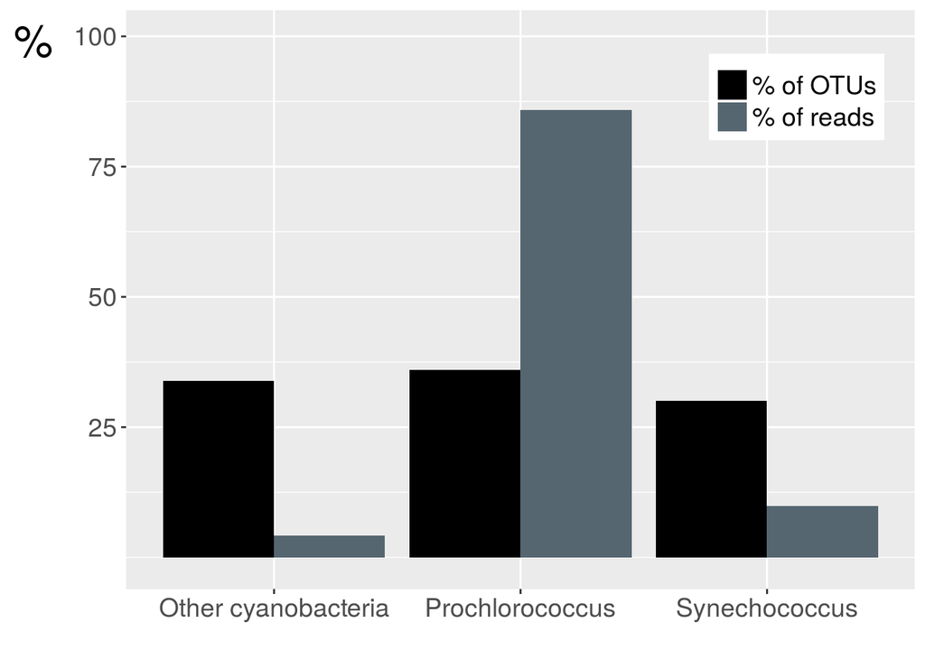

```r
ggplot(cyano_OTUs_reads_rel_abund2, aes(x=group, y=value, fill=data)) +
  geom_bar(position="dodge", stat="identity") +
  scale_y_continuous(limits=c(-1,100), breaks=c(25,50,75,100)) +
  scale_fill_manual(values=c("#000000", "#556670")) +
  labs(x="", y="% \n") +
  theme(axis.text=element_text(size=14), axis.title=element_text(size=16)) +
  theme(legend.title = element_blank(), legend.position=c(0.85,0.85), legend.text=element_text(size=14)) +
  theme(axis.title.y = element_text(size = rel(1.5), angle = 0, vjust=0.97))
```